# Probability Distributions

Logan Kelly, Ph.D.

Managerial Statistics - ECON 730

## Objectives

- After this lecture you should be able to use probability distributions in managerial decision making
- Topics:
  - Mean
  - Standard Deviation
  - Variances
  - Proportions
  - Normal and t-distributions
  - Sampling distributions
  - Confidence intervals

# 1 Case Background

## 1.1 Double E (EE) Chain of Consumer Electronics Stores

- EE is a chain of stores selling consumer electronics in the US
- EE suspects that the main reasons for declining profits are the falling quality of service and growing competition
- EE is concerned that it is spending too much time with pseudo customers
- EE has collated data on time spent with customers and whether the customer was a pseudo customer.

# 2 Probability Distributions

## 2.1 Probability Distributions

- A probability distribution allows us to compute the chance that a variable lies within a given range
- Examples:
  - Probability sales are between 10,000 and 50,000
  - Probability that a customer buys 2 items

## 2.2 Types

- Probability distributions can be
  - **Discrete:** only taking on certain values
  - **Continuous:** taking on any value within a range or set of ranges
- Examples:
  - The number of items that a customer buys follows a **discrete** probability distribution
  - The daily sales at EE follows a **continuous** probability distribution

## 2.3 Important Attributes

- **Mean:** The average or ‘expected value’ of a distribution.
  - Denoted by $\mu$ (The Greek letter mu)
- **Variance:** A measure of dispersion and volatility.
  - Denoted by $\sigma^2$ (Sigma Squared)
- **Standard deviation:** A related measure of dispersion computed as the square root of the variance.
  - Denoted by $\sigma$ (The Greek letter sigma)

## 2.4 Proportions

- Some variables take on only two values
  - Employee is Male/Female
  - Voters Approve/Disapprove
  - Customer buys something/doesn’t buy anything
- The **proportion** of customers who buy something at the store has special characteristics
- If a variable has a proportion, $p$, then we can show mathematically that its variance is $p(1-p)$ and the standard deviation is $\sqrt{p(1-p)}$

## 2.5 Normal Distribution

- One of the most common distributions in statistics is the normal distribution
- There are actually innumerable normal distributions, each characterized by two parameters:
  - The mean
  - The standard deviation
- The standard normal has a mean of zero and a standard deviation of one

## 2.6 The Normal Distribution: A Bell Curve

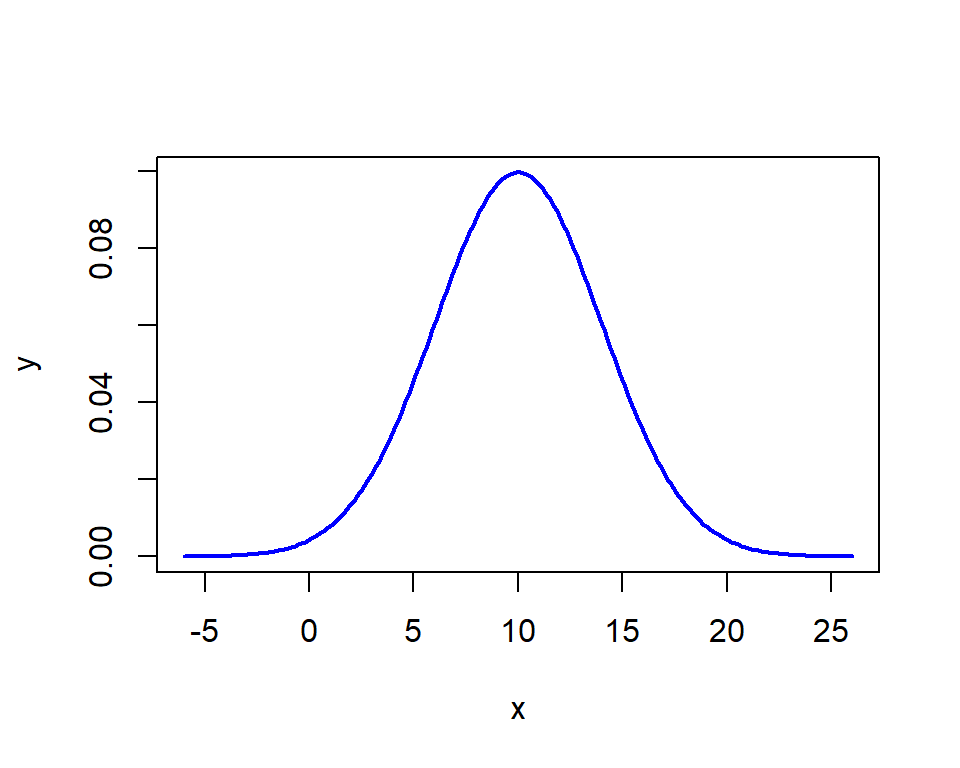

## 2.7 The Normal Distribution is Symmetric

The area under each half of the normal PDF is 0.5

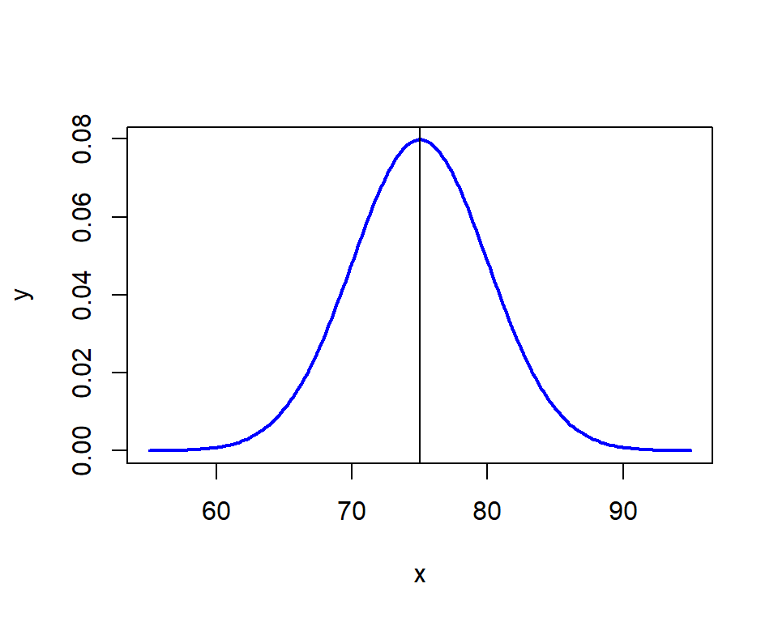

## 2.8 Calculating probabilities

- In this example, we will calculate the probability that a customer will purchase 14 items or more.
- We are told that the averge number of items purchased by a customer is a normally distributed random variable, the population mean is 10, $\mu=10$, and the population standard deviation is 4, $\sigma=4$.

## 2.9 The average number of items per customer

Shaded Area measures the probability that the average is greater than 14

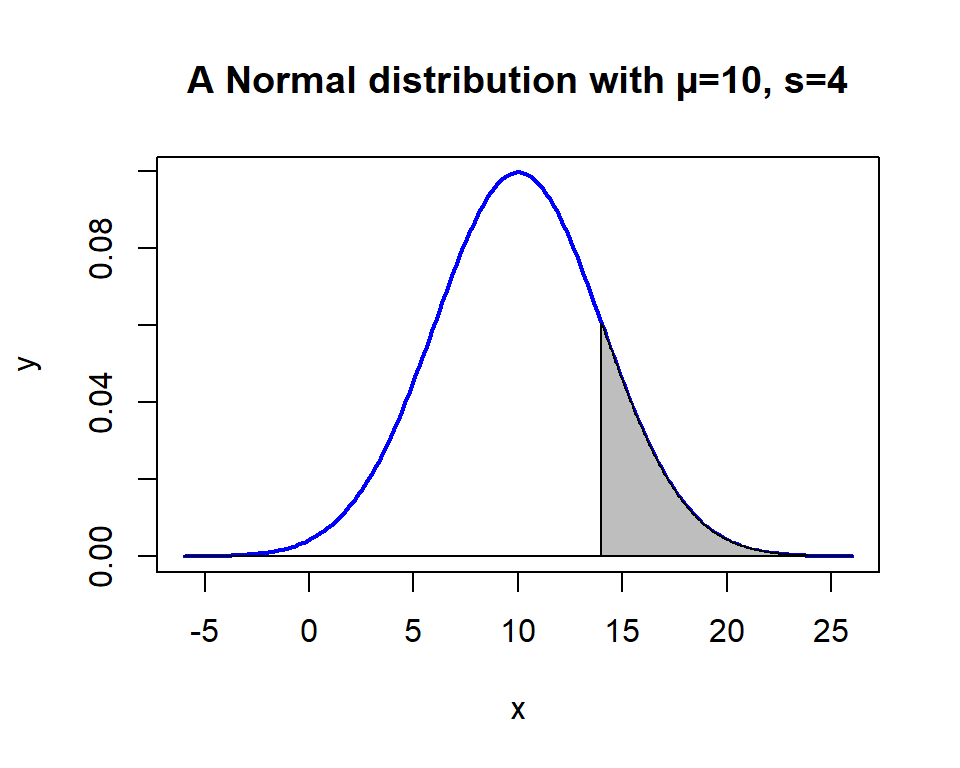

## 2.10 Calulating the probability that the average is greater than 14

```r
pnorm(q=14, mean=10, sd=4, lower.tail=F)
```

```
[1] 0.1586553
```

The probability that the average is less than 14 can be calulated by seting `lower.tail=T`

```r
pnorm(q=14, mean=10, sd=4, lower.tail=T)
```

```
[1] 0.8413447
```

## 2.11 What value of X gives an area of 0.3 to its left ?

```r
qnorm(p=0.3, mean=10, sd=4, lower.tail=T)
```

```
[1] 7.902398
```

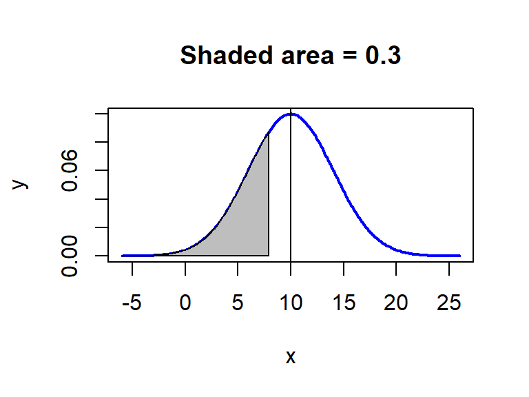

# 3 The Double E case

## 3.1 Count the number of pseudo customers

- Load the Case Data

  ```r
  pseudo.cust <- read.csv("data/EE_PseudoCustomers.csv")
  ```

- Count the number of pseudo customers
  - To calculate a frequency table, we use the `table()` command

  ```r
  attach(pseudo.cust)
  table(pseudo.customer)
  ```

  ```
  pseudo.customer
   0  1
  60 40
  ```

## 3.2 Calculate the mean service time for pesudo and true customers

- We need to install the “tidyverse” package
- The code `if (!require("tidyverse"))...` checks if the package has been installed and installs it if it is missing

  ```r
  if (!require("tidyverse")) install.packages("tidyverse")
  ```

## Calculate the mean (Cont.)

- Now we need to load the “tidyverse” package and calculate the average service time by customer type

  ```r
  library(tidyverse)
  pseudo.cust.avg <- pseudo.cust %>% group_by(pseudo.customer) %>%
    summarize(avg = mean(service.time))
  ```

- The pipe operator, `%<%`, can be interpreted as “with this do that.” So the command above means group the pseudo.cust data by customer type and then calculate the average of each group.

## Let’s see the resulults

```r
pseudo.cust.avg
```

```
# A tibble: 2 x 2
  pseudo.customer   avg
            <int> <dbl>
1               0 4584.
2               1 5324.
```

## 3.3 Comparing the two groups with boxplots

We can examine the difference in time spent with pseudo and true customers with side by side boxplots of the data: `boxplot(service.time~pseudo.customer)`

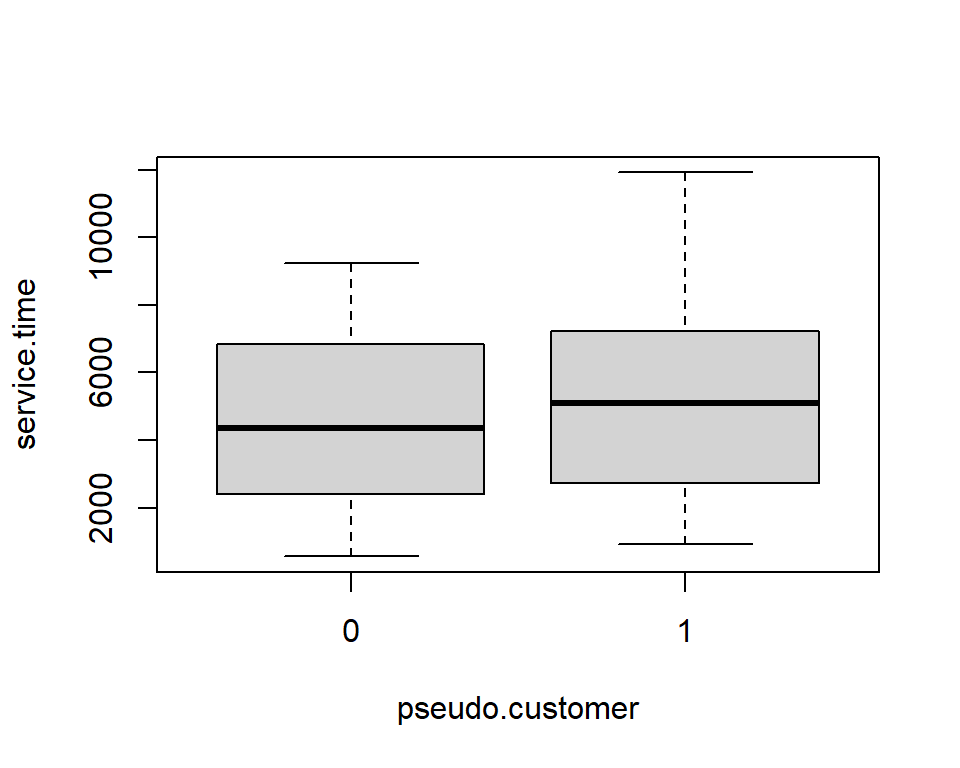

# 4 Calculate a 95% confidence interval

## 4.1 Confidence interval

- A confidence interval is an interval that contains the population parameter with probability $1-\alpha$

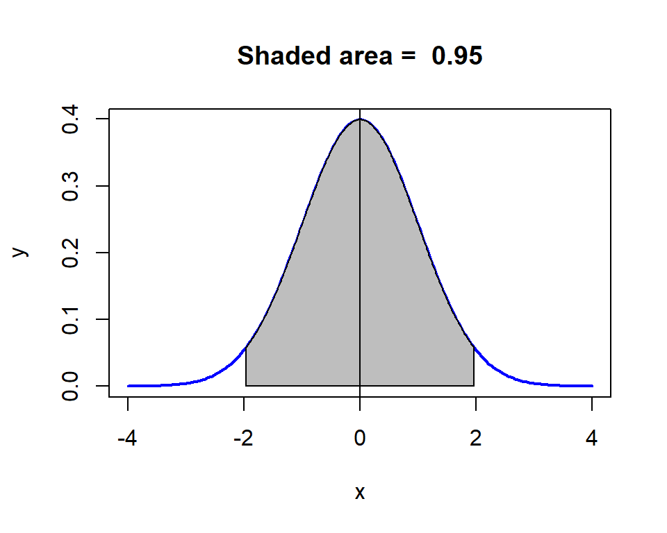

## 4.2 Confidence interval math

- A confidence interval takes on the form:
  $$\bar X \pm {t_{\alpha /2,N - 1}}{S_{\bar X}}$$
  - $t_{\alpha /2,N - 1}$ is the value needed to generate an area of α/2 in each tail of a t-distribution with n-1 degrees of freedom
  - ${S_{\bar X}} = \frac{s}{{\sqrt N }}$ is the standard error of the mean
- The confidence level is equal to $1-\alpha$

## 4.3 Calculate a confidence interval

To calculate a confidence interval, we need the following steps

1. Calculate the mean
2. Calculate the standard error of the mean
3. Find the t-score that corresponds to the confidence level
4. Calculate the margin of error and construct the confidence interval

## Step 1: Calculate the mean

- Use the `group_by()` and `summarize()` commands to calculate the average service time spent with pseudo and true customers.

```r
  pseudo.cust.avg <- pseudo.cust %>% group_by(pseudo.customer) %>%
    summarize(avg = mean(service.time))
```

- Store the averages in a vector, or list of numbers

```r
  avg.service.time <- pseudo.cust.avg$avg
  sample.mean <- avg.service.time[2]
```

## Step 2: Calculate the standard error of the mean

- The formula for the standard error of the mean is ${S_{\bar X}} = \frac{\sigma}{{\sqrt N }}$
- And if we do not know the population standard deviation ${S_{\bar X}} = \frac{s}{{\sqrt N }}$
- The `sd()` command can be used to find the standard deviations of the two samples

```r
  pseudo.cust.se <- pseudo.cust %>% group_by(pseudo.customer) %>%
    summarize(se = sd(service.time)/(n())^.5)
  se.service.time <- pseudo.cust.se$se
  sample.se <- se.service.time[2]
```

## Step 3: Find the t-score that corresponds to the confidence level

- We need to have $\alpha/2$ probability in the lower and upper tails, we divide by two because there are two tails.
- The `qt()` command will calculate the t-score, $t_{\alpha /2,N - 1}$

## Step 3: Find the t-score (Cont.)

```r
# Set Alpha
alpha = 0.05

# find N, number of pseudo customers
count.type <- table(pseudo.customer)
N = count.type[2]

# Calculate t-score
t.score = qt(p=alpha/2,N-1,lower.tail=F)

print(t.score)
```

```
[1] 2.022691
```

## Step 4. Calculate the margin of error and construct the confidence interval

- The margin of error is ${t_{\alpha /2,N - 1}}{S_{\bar X}}$

```r
  margin.error <- t.score * sample.se
```

- Construct the confidence interval

```r
  lower.bound <- sample.mean - margin.error
  upper.bound <- sample.mean + margin.error

  print(c(lower.bound,upper.bound))
```

```
[1] 4434.669 6213.181
```

# 5 A much easier way

## Let’s use linear regression as a short cut

```r
# Calculate the mean and standard error
l.model <- lm(service.time ~ 1,
              data=subset(pseudo.cust, pseudo.customer==1))

# Calculate the confidence interval
confint(l.model, level=0.95)
```

```
               2.5 %   97.5 %
(Intercept) 4434.669 6213.181
```